# IODS course project

Patricia Ribeiro

# Introduction to Open Data Science - Course Project

# About the project

```r
# This is a so-called "R chunk" where you can write R code.

date()
```

```
## [1] "Thu Dec 03 21:45:49 2020"
```

Hello! My name is Patricia and I am a doctoral student in **Language Studies**. I am a totally beginner in R but I would love to learn how to use it because it is important for my research. You can find more info about my course project here: [link](https://github.com/pat-rib/IODS-project)

# Task 2

*I studied data wrangling and practiced how to analyze data*

```r
date()
```

```
## [1] "Thu Dec 03 21:45:49 2020"
```

## Data wrangling exercises:

1. I created a dataset and performed data wrangling according to the task 2.
2. I Updated to correct the data.
3. I used the following codes to:
- Access the dplyr library: `library(dplyr)`
- Read the data into memory: `learning2014 <- read.table("http://www.helsinki.fi/~kvehkala/JYTmooc/JYTOPKYS2-data.txt", sep="\t", header=TRUE)`
- Get a summary of the structure of learning2014: `str(learning2014)`
- Retrieve the dimension of learnin2014: `dim(learning2014)`
- List the columns I wanted: `variableNames <- c("Gender","Age","Attitude", "Deep", "Stra", "Surf", "Points")`
- Select the columns from learning2014: `selectedData <- select(learning2014, one_of(variableNames))`
- Build the corresponding combination variables in the original dataset: `selectedData$Attitude <- selectedData$Attitude / 10` `selectedData$Deep <- selectedData$Deep / 12` `selectedData$Stra <- selectedData$Stra / 8` `selectedData$Surf <- selectedData$Surf / 12`
  - (Note: I divided each number in the column vector by the number of questions used)
- Select rows where points is greater than zero: `selectedData <- filter(selectedData, Points > 0)`
- Save the dataset: `write.table(selectedData, "learning2014.csv")`
- Read dataset: `newData <- read.table("learning2014.csv")`
- Demonstrate that I can read the data again: `str(newData)`
- Reading the data again: `head(newData)`

## Data analysis exercises

1. I read the data using the code: `learning2014 <- read.table("http://s3.amazonaws.com/assets.datacamp.com/production/course_2218/datasets/learning2014.txt", sep=",", header=TRUE)`

B)I used the following codes to:

- Explore the structure of the data: `str(learning2014)`
- Explore the dimension of the data: `dim(learning2014)`
3. Description of the dataset: it is a dataset that has 166 objects and 7 variables (gender, age, attitude, deep, stra, surf, and points).
4. I used the following codes to:
- Show a graphical overview of the data drawing a scatter plot matrix of the variables in learning2014: `plot(learning2014)`
- Show summaries of the variables: `summary(learning2014)`
- Access the gglot2 library: `library(ggplot2)`
- Choose 3 variables where points is the target and fit a linear model: `my_model <- lm(points ~ attitude + stra + surf, data = learning2014)`
- Show summaries of the model: `summary(my_model)`
5. Explanation of the relationship between the variables: the multiple R squared of the model shows that the explanatory variables “stra” and “surf” are not related to the target variable “points” because their p-values are too high.
6. I performed the following actions using the following codes to:
- Remove the explanatory variables “stra” and “surf” from the model: `my_model2 <- lm(points ~ attitude, data = learning2014)`
- Show the summaries of the model: `summary(my_model2)`
- Produce the following diagnostic plots: QQ-plot and Residual versus Leverage: `plot(my_model2, c(1, 2, 5))`
7. Assumptions of the model: the main assumption is that the modeling errors are normally distributed with equal variance.
8. Interpretation of the validity of the assumption: the variance of Residuals seems constant and independent of the fitted values. Normal QQ-plot shows very good feat for intermediate values but it deviates for small and high values.No significant leverage was observed. Concluding, the model provides a reasonable fit for the data, specially for intermediate values of the attitude variable.

# Exercise 3

*Logistic regression*

```r
date()
```

```
## [1] "Thu Dec 03 21:45:49 2020"
```

## Analysis

I start by reading the joined student alcohol consumption data set that I have created in the data wrangling task. I will also remove the first column added by read.csv and print out the the names of the variables in this data set:

```r
alc_data <- read.csv("data/alc_data.csv", header=TRUE)
alc_data <- alc_data[,-1]
colnames(alc_data)
```

```
##  [1] "school"     "sex"        "age"        "address"    "famsize"
##  [6] "Pstatus"    "Medu"       "Fedu"       "Mjob"       "Fjob"
## [11] "reason"     "nursery"    "internet"   "guardian"   "traveltime"
## [16] "studytime"  "failures"   "schoolsup"  "famsup"     "paid"
## [21] "activities" "higher"     "romantic"   "famrel"     "freetime"
## [26] "goout"      "Dalc"       "Walc"       "health"     "absences"
## [31] "G1"         "G2"         "G3"         "alc_use"    "high_use"
```

The data consist of 382 objects and 35 variables. It is a joined data set from two questionnaires that studied alcohol consumption and the school performance of the students in maths and Portuguese language. The data set contains only the data from the students that answered both questionnaires.  
Aiming to study the relationship between high alcohol consumption and some other variables, I will choose 4 variables from the data:

```r
variableNames <- c("sex","G3","absences", "studytime")
```

I have decided to use these variables because my hypothesis is that men are more suitable to woman to consume higher amount of alcohol and this fact can affect more their school performance, resulting in lower grades and more absences for men. Besides that, I think study time will be lower for those students with higher alcohol consumption.

Now I will explore numerically the distribution of my chosen variables, showing their relationship with alcohol consumption:

```r
library(dplyr)
```

```r
library(ggplot2)
alc_data %>% group_by(sex, high_use) %>% summarise(count = n(), mean_grade = mean(G3))
```

```
## # A tibble: 4 x 4
## # Groups:   sex [2]
##   sex   high_use count mean_grade
##   <chr> <lgl>    <int>      <dbl>
## 1 F     FALSE      156       11.4
## 2 F     TRUE        42       11.7
## 3 M     FALSE      112       12.2
## 4 M     TRUE        72       10.3
```

```r
alc_data %>% group_by(sex, high_use) %>% summarise(count = n(), mean_studytime = mean(studytime))
```

```
## # A tibble: 4 x 4
## # Groups:   sex [2]
##   sex   high_use count mean_studytime
##   <chr> <lgl>    <int>          <dbl>
## 1 F     FALSE      156           2.34
## 2 F     TRUE        42           2
## 3 M     FALSE      112           1.88
## 4 M     TRUE        72           1.64
```

```r
alc_data %>% group_by(sex, high_use) %>% summarise(count = n(), mean_absences = mean(absences))
```

```
## # A tibble: 4 x 4
## # Groups:   sex [2]
##   sex   high_use count mean_absences
##   <chr> <lgl>    <int>         <dbl>
## 1 F     FALSE      156          4.22
## 2 F     TRUE        42          6.79
## 3 M     FALSE      112          2.98
## 4 M     TRUE        72          6.12
```

Let’s see graphically how the distribution of my chosen variables relates with alcohol consumption:

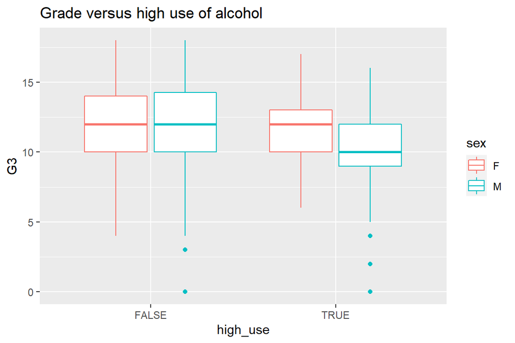

```r
g1 <- ggplot(alc_data, aes(x = high_use, y = G3, col = sex))
g1 + geom_boxplot() + ggtitle("Grade versus high use of alcohol")
```

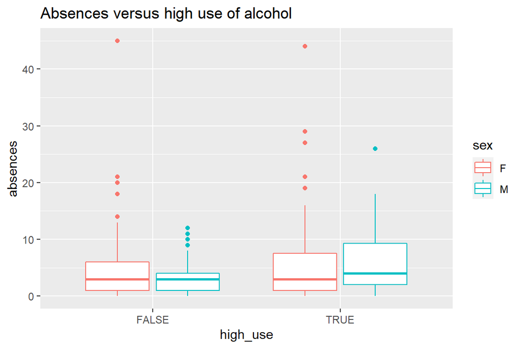

```r
g2 <- ggplot(alc_data, aes(x = high_use, y = absences, col = sex))
g2 + geom_boxplot() + ggtitle("Absences versus high use of alcohol")
```

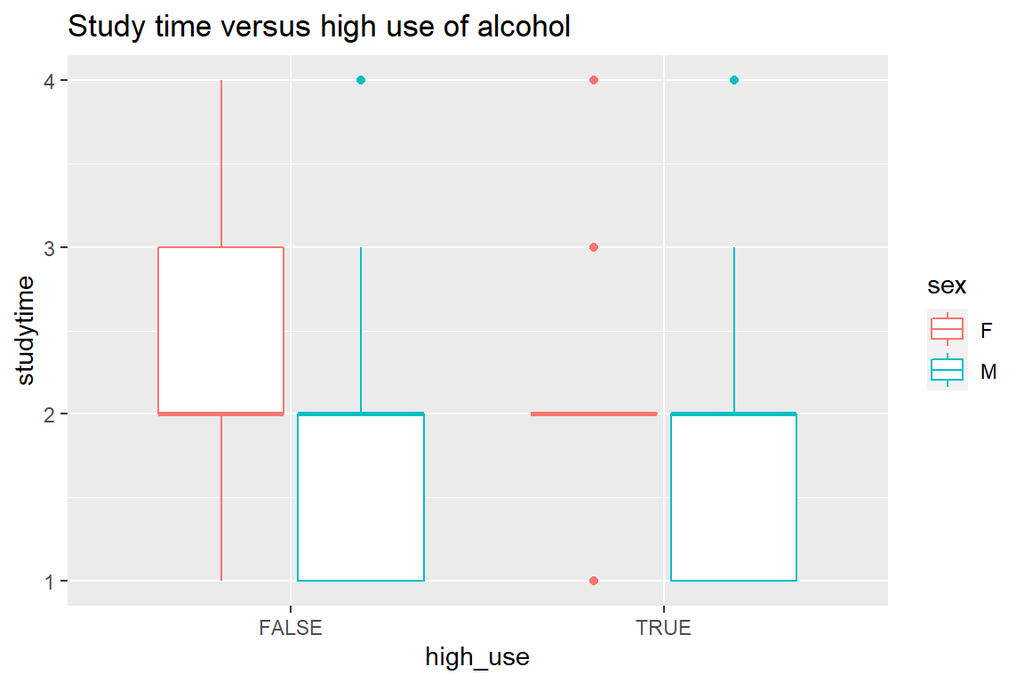

```r
g3 <- ggplot(alc_data, aes(x = high_use, y = studytime, col = sex))
g3 + geom_boxplot() + ggtitle("Study time versus high use of alcohol")
```

Next we will use logistic regression to explore the relationship between high/low alcohol consumption and the variables above.

```r
# find the model with glm()
m <- glm(high_use ~ G3 + absences + sex + studytime, data = alc_data, family = "binomial")
# print out a summary of the model
summary(m)
```

```
##
## Call:
## glm(formula = high_use ~ G3 + absences + sex + studytime, family = "binomial",
##     data = alc_data)
##
## Deviance Residuals:
##     Min       1Q   Median       3Q      Max
## -2.1651  -0.8305  -0.6080   1.0655   2.2203
##
## Coefficients:
##             Estimate Std. Error z value Pr(>|z|)
## (Intercept) -0.29816    0.54686  -0.545 0.585602
## G3          -0.06274    0.03649  -1.719 0.085552 .
## absences     0.08632    0.02300   3.753 0.000174 ***
## sexM         0.82362    0.25214   3.267 0.001089 **
## studytime   -0.35800    0.16106  -2.223 0.026232 *
## ---
## Signif. codes:  0 '***' 0.001 '**' 0.01 '*' 0.05 '.' 0.1 ' ' 1
##
## (Dispersion parameter for binomial family taken to be 1)
##
##     Null deviance: 465.68  on 381  degrees of freedom
## Residual deviance: 420.31  on 377  degrees of freedom
## AIC: 430.31
##
## Number of Fisher Scoring iterations: 4
```

```r
# print out the coefficients of the model
coef(m)
```

```
## (Intercept)          G3    absences        sexM   studytime
## -0.29815934 -0.06274264  0.08632235  0.82362397 -0.35799984
```

```r
# compute odds ratios (OR)
OR <- coef(m) %>% exp

# compute confidence intervals (CI)
confint(m)
```

```
##                   2.5 %       97.5 %
## (Intercept) -1.37564810  0.774669451
## G3          -0.13486805  0.008656709
## absences     0.04334686  0.133675206
## sexM         0.33364727  1.324143604
## studytime   -0.68277272 -0.049493637
```

```r
CI <- confint(m) %>% exp
# print out the odds ratios with their confidence intervals
cbind(OR, CI)
```

```
##                    OR     2.5 %    97.5 %
## (Intercept) 0.7421831 0.2526758 2.1698748
## G3          0.9391852 0.8738312 1.0086943
## absences    1.0901577 1.0443001 1.1430215
## sexM        2.2787430 1.3960506 3.7589648
## studytime   0.6990732 0.5052142 0.9517112
```

The model shows that the p-values for the variables “absences” and “sex” are low, indicating that they have good chances to be related with the target variable. The OR are greater than 1 for “absences” and “sex”, confirming their connection with high alcohol use. The values of OR within the confidence intervals for “absences” and “sex” are higher than 1, further confirming their strong relation with alcohol high use.

In the sequel I will focus the analysis on variables “sex” and “absences”. I will calculate again the logistic regression using only those two variables and explore the predictive power of the model.

```r
# Model with relevant statistical relationship
# find the model with glm()
m2 <- glm(high_use ~ sex + absences, data = alc_data, family = "binomial")

# compute odds ratios (OR)
OR <- coef(m2) %>% exp

# compute confidence intervals (CI)
CI <- confint(m2) %>% exp
# print out the odds ratios with their confidence intervals
cbind(OR, CI)
```

```
##                   OR     2.5 %    97.5 %
## (Intercept) 0.159445 0.1012577 0.2427684
## sexM        2.658116 1.6710354 4.2863129
## absences    1.101409 1.0549317 1.1548057
```

```r
# predict() the probability of high_use
probabilities <- predict(m2, type = "response")


# add the predicted probabilities to 'alc'
alc_data <- mutate(alc_data, probability = probabilities)

# use the probabilities to make a prediction of high_use
alc_data <- mutate(alc_data, prediction = probability > 0.5)

# tabulate the target variable versus the predictions
confusionTable <- table(high_use = alc_data$high_use, prediction = alc_data$prediction)
normTable <- confusionTable / dim(alc_data)[1]
wrongly <- normTable[2,1] + normTable[1,2]
print(paste("Total proportion of innacurately classified individuals: ", wrongly))
```

```
## [1] "Total proportion of innacurately classified individuals:  0.256544502617801"
```

The OR improved slightly when only the most significant variables where used to build the model. The model has a better performance than a simple guess since it has around 0.26 probability of error compared to the expected 0.5 probability of error of a simple guess.

Bonus task:

```r
# define a loss function (average prediction error)
loss_func <- function(class, prob) {
  n_wrong <- abs(class - prob) > 0.5
  mean(n_wrong)
}

# compute the average number of wrong predictions in the (training) data
loss_func(class = alc_data$high_use, prob = alc_data$probability)
```

```
## [1] 0.2565445
```

```r
# K-fold cross-validation
library(boot)
cv <- cv.glm(data = alc_data, cost = loss_func, glmfit = m2, K = 10)

# average number of wrong predictions in the cross validation
print(paste("Average number of wrong predictions in the cross validation: ", cv$delta[1]))
```

```
## [1] "Average number of wrong predictions in the cross validation:  0.267015706806283"
```

Performing 10-fold cross-validation, I can see that my model has approximately the same test set performance of the model introduced in DataCamp (about 0.26 error)